# Making Cross-Framework compatible models.

## *A guide to convert `arcgis.learn` PyTorch models to Tensorflow via Onnx*

# Who's the GOAT (Greatest of all time)?

[figure not shown]

### The never ending debate of supremacy

- Messi or Ronaldo
- Kobe or Jordan
- Marvel or DC

# Tensorflow or PyTorch

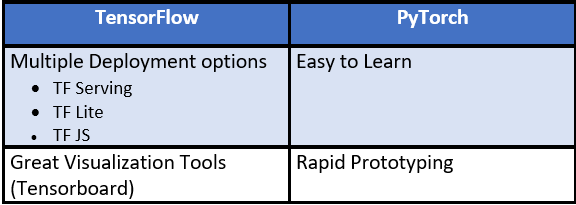

## **STOP** the war !!

We can't decide on who is better between Messi and Ronaldo or Kobe and Jordan. But we can enjoy watching them both and similarly we can enjoy the best of both Tensorflow and Pytorch worlds using Onnx. To reiterate, you can

- Build your model in PyTorch and deploy on Tensorflow
- Train your model in Tensorflow and perform inference on PyTorch

### All you need is a pinch of ONNX!!

## What is ONNX?

ONNX stands for Open Neural Network Exchange. ONNX is an open format to represent deep learning models. With ONNX, AI developers can more easily move models between state-of-the-art tools and choose the combination that is best for them.

More about ONNX at https://onnx.ai/

## Why do we need Tensorflow

## Because we are User centric

[figure not shown]

## Tensorflow is the clear winner when it comes to deployment

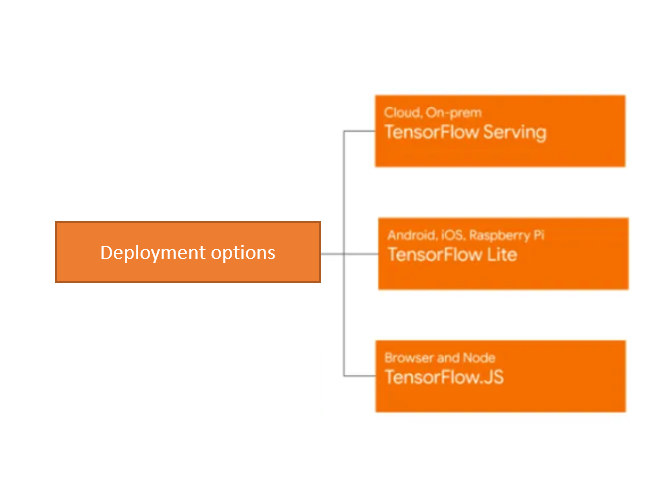

# This is how we do it

```python
# Imports

from arcgis.learn import SingleShotDetector, prepare_data
```

```python
# Prepare Data and Model

data_path = r'C:\Projects\Office work\Cross_platform_mobility\data\good_pool'

data = prepare_data(data_path,batch_size=16, val_split_pct=0.5)

ssd_model = SingleShotDetector(data, grids=[4],zooms=[1.0],ratios=[[1.0,1.0]])
```

```python
# Fit model to data and save it

ssd_model.fit(epochs=100, lr=0.0012)

ssd_model.save('ssd_model')
```

```python
# Load the model

ssd_model.load(r'C:\Projects\Office work\Cross_platform_mobility\data\good_pool\models\ssd_model')
```

## Convert model to TF-ONNX format

- Load a pretrained model
- Generate a new model by training.

#### Then,

```python
ssd_model.save('ssd_onnx', framework='tf-onnx')
```

```
WindowsPath('C:/Projects/Office work/Cross_platform_mobility/data/good_pool/models/ssd_onnx')
```

## Here are the generated model files

[figure not shown]

## What did we do just now?

- We saved our model as ONNX model file.
- Internally we convert this ONNX model to Tensorflow `GraphRep` object.
- Tensorflow `GraphRep` object can be used to perform inference on Tensorflow.